# Instalacja programów i pakietów R

Przygotowanie komputera na warsztaty prowadzone w ramach XXXII Ogólnopolskiej Szkoły Zintegrowanego Monitoringu Środowiska Przyrodniczego, Poznań, 23-24.09.2026 r.

Autor

Anna Dmowska (dmowska@amu.edu.pl)

*Materiały zostały opracowane z wykorzystaniem Claude*

**WskazówkaSzybki start (5 kroków)**

1. Zainstaluj **R** ze strony cran.r-project.org *(Etap 1)*.
2. Zainstaluj **RStudio Desktop** - to program z sekcji **RStudio IDE** na stronie docs.posit.co/ide/user/#rstudio-ide-oss-downloads *(Etap 2)*.
3. Uruchom RStudio, otwórz plik **`instaluj_pakiety.R`** i kliknij przycisk **Source** *(Etap 3-4)*.
4. Poczekaj kilkanaście minut. Skrypt sam pobierze wszystkie pakiety i **o nic nie zapyta** *(Etap 5-6)*.
5. Otwórz plik **`test.qmd`** i kliknij przycisk **Render**. Jeśli otworzy się dokument Word - komputer jest gotowy *(Etap 7)*.

Każdy z tych kroków jest **opisany szczegółowo w dalszej części instrukcji** - oznaczenia w nawiasach (*Etap 1*, *Etap 2*, …) wskazują, w którym miejscu szukać opisu. Jeśli coś jest jasne, wystarczy trzymać się listy powyżej; jeśli nie - opis znajdziesz niżej.

Wszystko robisz **jeden raz**. Przy kolejnych raportach ten dokument nie jest już potrzebny.

# 1 Dla kogo jest ta instrukcja

Instrukcja opisuje **niezbędne oprogramowanie**, które będzie używane w trakcie warsztatów pt. **„Nowe narzędzia informatyczne w realizacji programu Zintegrowanego Monitoringu Środowiska Przyrodniczego”**, prowadzonych na **XXXII Ogólnopolskiej Szkole Zintegrowanego Monitoringu Środowiska Przyrodniczego** (Poznań, 23-24.09.2026 r.).

Warsztaty dotyczą zastosowania automatyzacji w raportowaniu danych meteorologicznych (program A1) oraz danych hydrologicznych (program H1).

Instrukcja przygotowuje komputer do obu programów naraz:

- **A1** - raport meteorologiczny Stacji Bazowej,
- **H1** - raport i aneks hydrologiczny Stacji Bazowej.

Do instrukcji dołączone są dwa pliki:

| Plik | Do czego służy |
| --- | --- |
| `instaluj_pakiety.R` | Instaluje wszystkie pakiety potrzebne do A1 i H1 |
| `test.qmd` | Sprawdza, czy instalacja się udała |

Trzymaj oba pliki razem z tą instrukcją, w jednym folderze.

# 2 Zanim zaczniesz

Potrzebujesz:

1. **Komputera** z systemem Windows, macOS albo Linux. Instrukcja pokazuje, jak przeprowadzić instalację dla systemu operacyjnego Windows; na pozostałych systemach kroki są takie same, różnią się tylko pliki instalacyjne do pobrania.
2. **Połączenia z internetem** - pakiety pobierają się z serwera CRAN.
3. **Około godziny czasu** przy pierwszej instalacji. Same programy R i RStudio instalują się w kilka minut, ale pobranie pakietów potrafi zająć **od kilkunastu do trzydziestu minut** - pakietów wraz z ich zależnościami jest ponad sto.
4. **Prawa do instalowania programów** na tym komputerze. Na komputerze służbowym może być potrzebna pomoc informatyka - poproś o zainstalowanie R i RStudio. Pakiety R instalują się już bez uprawnień administratora.

# 3 Jakie oprogramowanie trzeba zainstalować

Programy instaluj **w tej kolejności** - RStudio szuka R przy pierwszym uruchomieniu i musi go już zastać na dysku.

| Kolejność | Program | Konieczny? | Skąd pobrać |
| --- | --- | --- | --- |
| 1 | **R** | tak | cran.r-project.org |
| 2 | **RStudio Desktop** | tak | [posit.co/download/rstudio-desktop](https://posit.co/download/rstudio-desktop/) |
| 3 | **Quarto** | zwykle już jest | quarto.org |
| 4 | **Word** (lub LibreOffice) | do czytania wyniku | - |

**R** to program, który wykonuje obliczenia. Sam w sobie jest niewygodny w obsłudze, dlatego prawie nikt nie używa go bezpośrednio.

**RStudio** to okno, w którym pracujesz: otwierasz w nim pliki i klikasz przyciski. Wersja **RStudio Desktop (Open Source, darmowa)** w zupełności wystarczy.

**Quarto** to program, który składa gotowy raport w Wordzie z pliku z kodem (rozszerzenie `.qmd`). Nowsze wersje RStudio mają Quarto **wbudowane** - najczęściej nie trzeba instalować go osobno. Skrypt `instaluj_pakiety.R` sam sprawdzi, czy Quarto jest, i napisze w konsoli, jeśli go zabraknie.

## Etap 1: instalacja R

1. Wejdź na cran.r-project.org.
2. Kliknij **Download R for Windows** (albo *for macOS*, jeśli masz Maca).
3. Kliknij **base**, a potem duży link **Download R x.x.x for Windows**.
4. Uruchom pobrany plik i przeklikaj instalator, **nic nie zmieniając** - wszystkie domyślne ustawienia są dobre.

## Etap 2: instalacja RStudio

1. Wejdź na [posit.co/download/rstudio-desktop](https://posit.co/download/rstudio-desktop/).
2. Przejdź do sekcji **RStudio IDE** z plikami do pobrania (*Open Source*). Bezpośredni link do tej sekcji: docs.posit.co/ide/user/#rstudio-ide-oss-downloads.
3. Wybierz wersję zgodną z Twoim systemem operacyjnym - dla **Windows 11** jest to pozycja *Windows 11/10* (plik z rozszerzeniem `.exe`).
4. Uruchom pobrany plik i przeklikaj instalator, nic nie zmieniając.
5. Uruchom RStudio. Przy **pierwszym uruchomieniu** program pyta, której wersji R ma używać - pojawia się okno **Choose R Installation** (Rycina 1). Zaznacz **trzecią opcję**, *Choose a specific version of R*, wybierz z listy wersję R zainstalowaną przed chwilą w Etapie 1 i kliknij **OK**. (Na macOS i Linuksie to okno zwykle się nie pojawia - RStudio znajduje R samo.)
6. Okno RStudio powinno wyglądać jak na rycinie niżej (Rycina 2).

**OstrzeżeniePobierz RStudio IDE, a nie RStudio Server**

Na stronie do pobrania są dwa różne programy o podobnej nazwie:

- **RStudio IDE** (nazywane też *RStudio Desktop*) - **ten jest Ci potrzebny**. Program instalowany na własnym komputerze.
- **RStudio Server** - wersja dla administratorów, instalowana na serwerze i obsługiwana przez przeglądarkę. **Nie pobieraj jej.**

Wybierz też wersję **Open Source** (darmową), a nie *Pro*.

[figure not shown]

Rycina 1: Okno **Choose R Installation** przy pierwszym uruchomieniu RStudio. Zaznacz trzecią opcję - *Choose a specific version of R* - i wskaż wersję zainstalowaną w Etapie 1 (na rycinie: `C:\Program Files\R\R-4.6.1`).

[figure not shown]

Rycina 2: Puste okno RStudio zaraz po uruchomieniu - tak wygląda program, zanim otworzysz w nim jakikolwiek plik.

Okno jest podzielone na części:

- **po lewej: Console (konsola)** - tam R wypisuje komunikaty i tam widać postęp instalacji,
- **prawa górna: Environment** - lista danych wczytanych do pamięci, na początku pusta,
- **prawa dolna: Files, Plots, Packages, Help** - m.in. lista plików w bieżącym folderze.

Gdy otworzysz plik z kodem, konsola zejdzie na dół, a nad nią pojawi się czwarta część okna - z tekstem tego pliku.

**Wskazówka**

Od tej pory **otwierasz wyłącznie RStudio**. Programu R nigdy nie uruchamiasz bezpośrednio - RStudio używa go w tle.

# 4 Jakie pakiety są potrzebne

**Pakiet** to dodatek do R - zestaw gotowych funkcji, na przykład do rysowania wykresów albo do łączenia się z bazą danych. R po zainstalowaniu ma tylko podstawowe funkcje, resztę trzeba dobrać samemu. Pakiety pobiera się raz i zostają na dysku.

Poniższa tabela pokazuje komplet pakietów dla obu programów. Kolumny A1 i H1 mówią, który program którego pakietu używa.

Pakiety potrzebne programom A1 i H1

| Pakiet | A1 | H1 | Do czego służy |
| --- | --- | --- | --- |
| `RPostgres` | tak | tak | połączenie z bazą danych ZMŚP (PostgreSQL) |
| `DBI` | tak | tak | wspólny interfejs do baz danych |
| `readxl` | tak | tak | czytanie pliku `parametry/parametry.xlsx` |
| `tidyverse` | tak | tak | przetwarzanie danych i ryciny (zawiera m.in. `ggplot2`, `dplyr`, `tidyr`) |
| `cowplot` | tak | tak | składanie kilku rycin w jedną |
| `svglite` | tak | tak | zapis rycin do plików SVG |
| `flextable` | tak | tak | tabele w raporcie Word |
| `openxlsx` | tak | tak | zapis tabel do pliku Excela |
| `quarto` | tak | tak | złożenie raportu Word z pliku `.qmd` |
| `scales` | tak | - | formatowanie osi i etykiet na rycinach |
| `ggrepel` | tak | - | etykiety na rycinach, które na siebie nie nachodzą |
| `RColorBrewer` | tak | - | palety kolorów |
| `trend` | tak | - | testy trendu (Manna-Kendalla) |
| `knitr` | tak | tak | wykonanie kodu R wewnątrz dokumentu `.qmd` |
| `rmarkdown` | tak | tak | obsługa dokumentów `.qmd` (używa go pakiet `quarto`) |
| `rstudioapi` | tak | tak | ustalenie katalogu roboczego przy uruchomieniu z RStudio |

**W praktyce instalujesz wszystkie naraz** - dołączony skrypt robi dokładnie to. Nadmiarowe pakiety niczemu nie szkodzą: każdy program wczytuje tylko te, których potrzebuje.

**AdnotacjaSkąd 16 pakietów, skoro instalują się setki**

Każdy pakiet korzysta z innych pakietów - to jego **zależności** (*dependencies*). Sam `tidyverse` wciąga ich kilkadziesiąt. R pobiera je automatycznie; dlatego w konsoli przewijają się nazwy, których nie ma w powyższej tabeli. Tak ma być.

# 5 Instalacja pakietów krok po kroku

## Etap 3: otwórz skrypt w RStudio

1. Uruchom **RStudio**.
2. Z menu wybierz **File → Open File…**
3. Wskaż plik **`instaluj_pakiety.R`** i kliknij **Open**.
4. Kod pojawi się w oknie w lewej górnej części RStudio. **Niczego w nim nie zmieniaj.**

**AdnotacjaŻółty pasek „Package quarto required but is not installed”**

Nad kodem może pojawić się żółty pasek z napisem **Package quarto required but is not installed. Install | Don’t show for this file** (Rycina 3). **Zignoruj go - nie klikaj *Install*.** RStudio zauważyło, że skrypt korzysta z pakietu `quarto`, którego jeszcze nie ma na komputerze. Ten pakiet - razem ze wszystkimi pozostałymi - zainstaluje za chwilę sam skrypt. Pasek możesz zamknąć krzyżykiem po prawej stronie.

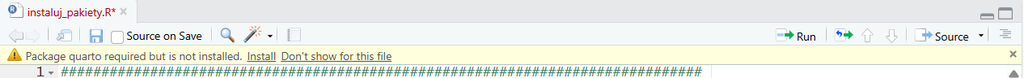

Rycina 3: Żółty pasek z informacją o brakującym pakiecie `quarto`, widoczny po otwarciu pliku `instaluj_pakiety.R`. Można go zignorować.

## Etap 4: kliknij Source

W prawym górnym rogu okna z kodem znajduje się przycisk **Source** (ikona strzałki) - Rycina 4. Kliknij go.

Odpowiednik z klawiatury: **Ctrl+Shift+S** (na macOS **Cmd+Shift+S**).

[figure not shown]

Rycina 4: Przycisk **Source** w pasku nad oknem z kodem, w jego prawym górnym rogu (zaznaczony czerwoną ramką).

**OstrzeżenieSource, nie Run**

Przycisk **Run** wykonuje tylko jedną, zaznaczoną linię. **Source** wykonuje cały plik od początku do końca - i o to nam chodzi.

## Etap 5: poczekaj

W konsoli (lewe dolne okno) zacznie przewijać się tekst - to normalne. Instalacja trwa **od kilkunastu do trzydziestu minut** i przez ten czas RStudio może wyglądać na „zamrożone”. Nie zamykaj go i nie klikaj Source drugi raz.

W lewym górnym rogu konsoli widać czerwony znak **stop** - dopóki tam jest, praca trwa.

## Etap 6: sprawdź podsumowanie

Gdy skrypt skończy, na dole konsoli pojawi się podsumowanie:

```
=== Sprawdzenie ===
  [OK]    RPostgres
  [OK]    readxl
  ...
=== Podsumowanie ===
  Pakiety: komplet (16 pakietów).
  Quarto:  C:/Program Files/RStudio/resources/app/bin/quarto/bin/quarto.exe
>>> Gotowe. Następny krok: otwórz plik test.qmd i kliknij Render.
```

- Wszystkie linie **`[OK]`** i napis **„komplet”** - instalacja się udała, przejdź do Sekcja 6.
- Choć jedna linia **`[BRAK]`** - kliknij **Source** jeszcze raz. Zdarza się, że pobieranie jednego pakietu urwie się przez chwilowy problem z siecią, a drugie podejście kończy się powodzeniem. Jeśli braki zostają, zajrzyj do Sekcja 7.
- Napis **„Quarto: NIE ZNALEZIONO”** - zainstaluj Quarto ze strony quarto.org, **zamknij i uruchom RStudio ponownie**, po czym kliknij Source jeszcze raz.

**Adnotacja**

Czerwony kolor tekstu w konsoli **nie oznacza błędu** - R wypisuje na czerwono także zwykłe komunikaty o postępie. Liczy się podsumowanie na końcu.

# 6 Test: czy wszystko działa

Pakiety to jedno, a program **Quarto** - drugie. Dołączony plik `test.qmd` sprawdza obie rzeczy naraz: wykonuje trochę kodu R, rysuje rycinę, formatuje tabelę i składa z tego dokument Worda - dokładnie tak, jak robią to raporty A1 i H1, tylko na zmyślonych danych i w kilka sekund.

## Etap 7: otwórz i wyrenderuj test.qmd

1. W RStudio wybierz **File → Open File…** i wskaż plik **`test.qmd`**.
2. Nad oknem z tekstem pojawi się przycisk **Render** (ikona niebieskiej strzałki) - Rycina 5. Kliknij go. Odpowiednik z klawiatury: **Ctrl+Shift+K** (macOS: **Cmd+Shift+K**).
3. Poczekaj kilkanaście sekund. W dolnej części RStudio otworzy się zakładka **Background Jobs** albo **Render** z przewijającym się tekstem.

[figure not shown]

Rycina 5: Przycisk **Render** w pasku nad oknem z tekstem pliku `test.qmd` (zaznaczony czerwoną ramką).

## Co powinno się stać

- Obok pliku `test.qmd` powstanie plik **`test.docx`**, a Word (lub LibreOffice) otworzy go automatycznie.
- W dokumencie zobaczysz tabelę z wersją R, tabelę z przykładowymi danymi i słupkowy wykres opadu.

**Jeśli dokument się otworzył - komputer jest gotowy.** Znaczy to, że działa R, działają pakiety i działa Quarto.

**Adnotacja**

Gdyby dokument nie otworzył się sam, poszukaj pliku `test.docx` w tym samym folderze co `test.qmd` i otwórz go ręcznie.

# 7 Gdy coś nie działa

| Komunikat lub objaw | Co zrobić |
| --- | --- |
| `there is no package called "..."` | Pakiet się nie zainstalował. Uruchom `instaluj_pakiety.R` ponownie (Source). |
| `package "..." is not available for this version of R` | Masz starą wersję R. Zainstaluj R na nowo z cran.r-project.org (Etap 1) i powtórz instalację pakietów. |
| `Nie znaleziono programu Quarto` | Zainstaluj Quarto z quarto.org, zamknij i otwórz RStudio ponownie, kliknij Source jeszcze raz. |
| `cannot open URL` / `unable to access index for repository` | Brak połączenia z internetem albo blokada firewalla lub proxy. Sprawdź połączenie; na komputerze służbowym poproś informatyka o odblokowanie adresu `cloud.r-project.org`. |
| `'lib = "C:/Program Files/R/..."' is not writable` | Brak prawa zapisu do katalogu z pakietami. Skrypt sam tworzy prywatny katalog użytkownika i to omija - upewnij się, że instalujesz **przez skrypt**, a nie ręcznie. |
| Instalacja stoi na pytaniu `(Yes/no/cancel)` | Wpisz `no` i naciśnij Enter - to znaczy: weź wersję gotową, nie buduj jej na tym komputerze. Skrypt `instaluj_pakiety.R` sam tego pilnuje, więc pytanie może pojawić się tylko przy instalacji ręcznej. |
| Żółty pasek `Package quarto required but is not installed` nad kodem | Zignoruj go, nie klikaj *Install*. Pakiet `quarto` zainstaluje skrypt `instaluj_pakiety.R`. |
| RStudio wygląda na zawieszone | Sprawdź, czy w rogu konsoli jest czerwony znak **stop**. Jeśli tak - instalacja trwa, poczekaj. |
| `test.docx` się nie tworzy, a w logu jest `pandoc` albo `LaTeX` | Sprawdź, czy plik `test.docx` nie jest właśnie otwarty w Wordzie - otwarty plik blokuje zapis. Zamknij go i kliknij Render ponownie. |

Gdy problem zostaje, prześlij osobie, która przekazała Ci projekt:

1. treść komunikatu z konsoli (zaznacz, skopiuj, wklej do wiadomości),
2. wynik polecenia `sessionInfo()` wpisanego w konsoli - podaje wersję R, system i listę wczytanych pakietów.